# R Notebook

```r
library(tidyverse)
library(modelr)
library(janitor)
library(dplyr)

# visualisation packages
library(ggiraphExtra)
library(GGally)
```

```r
 avocado <- read_csv("data/avocado.csv")
 data_dic <- read_csv("data/data_dict.txt")
head(avocado)
```

| X1 | Date | AveragePrice | Total Volume | 4046 | 4225 | 4770 | Total Bags | Small Bags | Large Bags | XLarge Bags | type | year | region |
| --- | --- | --- | --- | --- | --- | --- | --- | --- | --- | --- | --- | --- | --- |
| 0 | 2015-12-27 | 1.33 | 64236.62 | 1036.74 | 54454.85 | 48.16 | 8696.87 | 8603.62 | 93.25 | 0 | conventional | 2015 | Albany |
| 1 | 2015-12-20 | 1.35 | 54876.98 | 674.28 | 44638.81 | 58.33 | 9505.56 | 9408.07 | 97.49 | 0 | conventional | 2015 | Albany |
| 2 | 2015-12-13 | 0.93 | 118220.22 | 794.70 | 109149.67 | 130.50 | 8145.35 | 8042.21 | 103.14 | 0 | conventional | 2015 | Albany |
| 3 | 2015-12-06 | 1.08 | 78992.15 | 1132.00 | 71976.41 | 72.58 | 5811.16 | 5677.40 | 133.76 | 0 | conventional | 2015 | Albany |
| 4 | 2015-11-29 | 1.28 | 51039.60 | 941.48 | 43838.39 | 75.78 | 6183.95 | 5986.26 | 197.69 | 0 | conventional | 2015 | Albany |
| 5 | 2015-11-22 | 1.26 | 55979.78 | 1184.27 | 48067.99 | 43.61 | 6683.91 | 6556.47 | 127.44 | 0 | conventional | 2015 | Albany |

```r
NA
```

```r
glimpse(avocado)
```

```
Observations: 18,249
Variables: 14
$ X1             <dbl> 0, 1, 2, 3, 4, 5, 6, 7, 8, 9, 10, 11, 12, 13, 14, 15, 16, 17, 18, 19, 20, 21, 22, 23,…
$ Date           <date> 2015-12-27, 2015-12-20, 2015-12-13, 2015-12-06, 2015-11-29, 2015-11-22, 2015-11-15, …
$ AveragePrice   <dbl> 1.33, 1.35, 0.93, 1.08, 1.28, 1.26, 0.99, 0.98, 1.02, 1.07, 1.12, 1.28, 1.31, 0.99, 1…
$ `Total Volume` <dbl> 64236.62, 54876.98, 118220.22, 78992.15, 51039.60, 55979.78, 83453.76, 109428.33, 998…
$ `4046`         <dbl> 1036.74, 674.28, 794.70, 1132.00, 941.48, 1184.27, 1368.92, 703.75, 1022.15, 842.40, …
$ `4225`         <dbl> 54454.85, 44638.81, 109149.67, 71976.41, 43838.39, 48067.99, 73672.72, 101815.36, 873…
$ `4770`         <dbl> 48.16, 58.33, 130.50, 72.58, 75.78, 43.61, 93.26, 80.00, 85.34, 113.00, 117.07, 105.3…
$ `Total Bags`   <dbl> 8696.87, 9505.56, 8145.35, 5811.16, 6183.95, 6683.91, 8318.86, 6829.22, 11388.36, 862…
$ `Small Bags`   <dbl> 8603.62, 9408.07, 8042.21, 5677.40, 5986.26, 6556.47, 8196.81, 6266.85, 11104.53, 806…
$ `Large Bags`   <dbl> 93.25, 97.49, 103.14, 133.76, 197.69, 127.44, 122.05, 562.37, 283.83, 564.45, 327.80,…
$ `XLarge Bags`  <dbl> 0.00, 0.00, 0.00, 0.00, 0.00, 0.00, 0.00, 0.00, 0.00, 0.00, 0.00, 0.00, 0.00, 0.00, 0…
$ type           <chr> "conventional", "conventional", "conventional", "conventional", "conventional", "conv…
$ year           <dbl> 2015, 2015, 2015, 2015, 2015, 2015, 2015, 2015, 2015, 2015, 2015, 2015, 2015, 2015, 2…
$ region         <chr> "Albany", "Albany", "Albany", "Albany", "Albany", "Albany", "Albany", "Albany", "Alba…
```

```r
avocado_tidy <- avocado %>%
  select(-Date, - region) %>%
  mutate(type = as.factor(type)) %>%
  rename(total_volume = 3, plu_4046 = 4, plu_4225 = 5, plu_4770 = 6)


glimpse(avocado_tidy)
```

```
Observations: 18,249
Variables: 12
$ X1            <dbl> 0, 1, 2, 3, 4, 5, 6, 7, 8, 9, 10, 11, 12, 13, 14, 15, 16, 17, 18, 19, 20, 21, 22, 23,…
$ AveragePrice  <dbl> 1.33, 1.35, 0.93, 1.08, 1.28, 1.26, 0.99, 0.98, 1.02, 1.07, 1.12, 1.28, 1.31, 0.99, 1…
$ total_volume  <dbl> 64236.62, 54876.98, 118220.22, 78992.15, 51039.60, 55979.78, 83453.76, 109428.33, 998…
$ plu_4046      <dbl> 1036.74, 674.28, 794.70, 1132.00, 941.48, 1184.27, 1368.92, 703.75, 1022.15, 842.40, …
$ plu_4225      <dbl> 54454.85, 44638.81, 109149.67, 71976.41, 43838.39, 48067.99, 73672.72, 101815.36, 873…
$ plu_4770      <dbl> 48.16, 58.33, 130.50, 72.58, 75.78, 43.61, 93.26, 80.00, 85.34, 113.00, 117.07, 105.3…
$ `Total Bags`  <dbl> 8696.87, 9505.56, 8145.35, 5811.16, 6183.95, 6683.91, 8318.86, 6829.22, 11388.36, 862…
$ `Small Bags`  <dbl> 8603.62, 9408.07, 8042.21, 5677.40, 5986.26, 6556.47, 8196.81, 6266.85, 11104.53, 806…
$ `Large Bags`  <dbl> 93.25, 97.49, 103.14, 133.76, 197.69, 127.44, 122.05, 562.37, 283.83, 564.45, 327.80,…
$ `XLarge Bags` <dbl> 0.00, 0.00, 0.00, 0.00, 0.00, 0.00, 0.00, 0.00, 0.00, 0.00, 0.00, 0.00, 0.00, 0.00, 0…
$ type          <fct> conventional, conventional, conventional, conventional, conventional, conventional, c…
$ year          <dbl> 2015, 2015, 2015, 2015, 2015, 2015, 2015, 2015, 2015, 2015, 2015, 2015, 2015, 2015, 2…
```

First predictor

We wnt to build an explanatory model

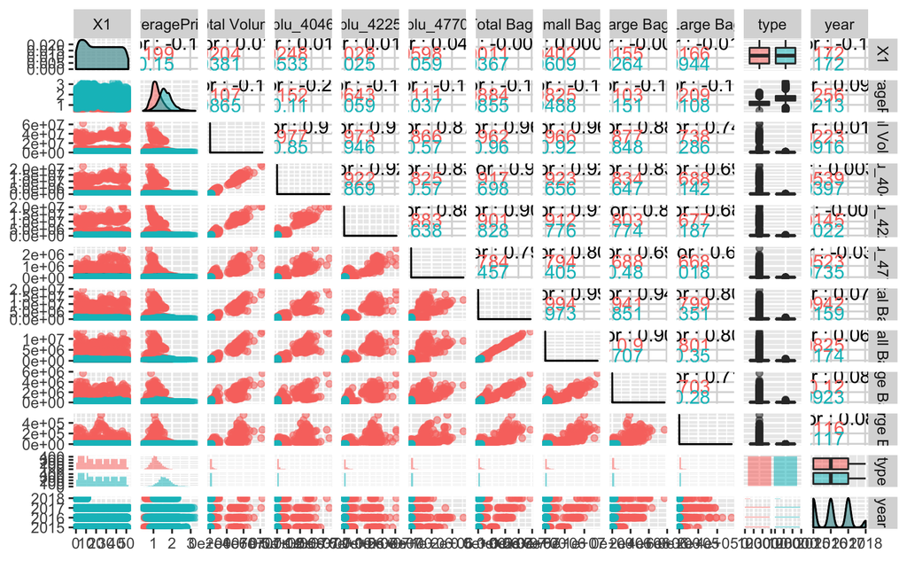

```r
avocado_tidy %>%
  ggpairs(aes(color = type, alpha = 0.5))
```

```r
NA
NA
```

Now comes the manual model building part. Let’s build seperate models and choose between them on the basis of r2

and diagnostics.

Let’s start with average price

```r
# build a model which tries to predict average price from plu4046

mod1a <- lm(formula = AveragePrice ~ total_volume, data = avocado_tidy)
mod1a
```

```
Call:
lm(formula = AveragePrice ~ total_volume, data = avocado_tidy)

Coefficients:
 (Intercept)  total_volume
   1.425e+00    -2.247e-08
```

This equation tells us that the predicted averageprice will vary decrease by 0.00000002 for every one unit increase in totalvolume.

We can then use the summary function to provide more information:

```r
summary(mod1a)
```

```
Call:
lm(formula = AveragePrice ~ total_volume, data = avocado_tidy)

Residuals:
     Min       1Q   Median       3Q      Max
-0.98366 -0.29994 -0.03319  0.25498  1.82528

Coefficients:
               Estimate Std. Error t value Pr(>|t|)
(Intercept)   1.425e+00  3.012e-03  473.07   <2e-16 ***
total_volume -2.247e-08  8.470e-10  -26.54   <2e-16 ***
---
Signif. codes:  0 ‘***’ 0.001 ‘**’ 0.01 ‘*’ 0.05 ‘.’ 0.1 ‘ ’ 1

Residual standard error: 0.3951 on 18247 degrees of freedom
Multiple R-squared:  0.03715,   Adjusted R-squared:  0.0371
F-statistic: 704.1 on 1 and 18247 DF,  p-value: < 2.2e-16
```

So, what does this tell us?

It tells us that our r2 value is really low (0.037) and so we can explain on 3% of the variance.So that’s not the most perfect prediction out there.

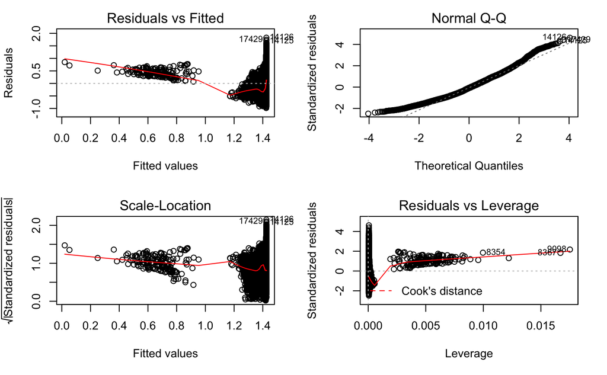

```r
# set our plotting parameter limits (2x2 graph)
par(mfrow = c(2, 2))

# plot
plot(mod1a)
```

```r
#type

model1b <- lm(formula = AveragePrice ~ type, data = avocado_tidy)

 summary(model1b)
```

```
Call:
lm(formula = AveragePrice ~ type, data = avocado_tidy)

Residuals:
     Min       1Q   Median       3Q      Max
-1.21400 -0.20400 -0.02804  0.18600  1.59600

Coefficients:
            Estimate Std. Error t value Pr(>|t|)
(Intercept) 1.158040   0.003321   348.7   <2e-16 ***
typeorganic 0.495959   0.004697   105.6   <2e-16 ***
---
Signif. codes:  0 ‘***’ 0.001 ‘**’ 0.01 ‘*’ 0.05 ‘.’ 0.1 ‘ ’ 1

Residual standard error: 0.3173 on 18247 degrees of freedom
Multiple R-squared:  0.3793,    Adjusted R-squared:  0.3792
F-statistic: 1.115e+04 on 1 and 18247 DF,  p-value: < 2.2e-16
```

model1b shows higher r-squared value around 37% significantly higher than first predictor

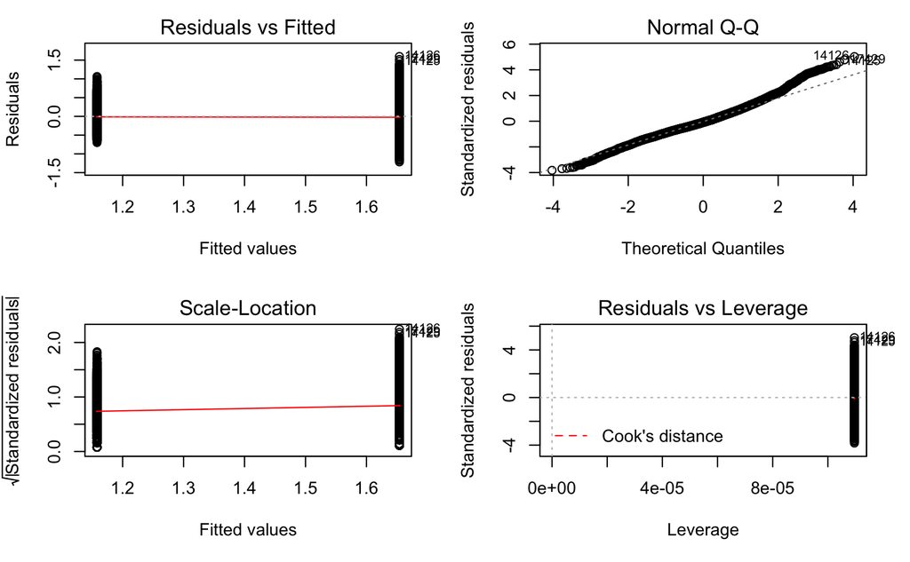

```r
par(mfrow = c(2, 2))

plot(model1b)
```

adding more predictors

```r
model2a <- lm(formula = lm(formula = AveragePrice ~ type + plu_4225 + plu_4770, data = avocado_tidy))

summary(model2a)
```

```
Call:
lm(formula = lm(formula = AveragePrice ~ type + plu_4225 + plu_4770,
    data = avocado_tidy))

Residuals:
    Min      1Q  Median      3Q     Max
-1.2139 -0.2032 -0.0241  0.1852  1.5960

Coefficients:
              Estimate Std. Error t value Pr(>|t|)
(Intercept)  1.164e+00  3.505e-03 332.070  < 2e-16 ***
typeorganic  4.897e-01  4.816e-03 101.686  < 2e-16 ***
plu_4225     2.251e-08  4.249e-09   5.298 1.18e-07 ***
plu_4770    -4.178e-07  4.737e-08  -8.821  < 2e-16 ***
---
Signif. codes:  0 ‘***’ 0.001 ‘**’ 0.01 ‘*’ 0.05 ‘.’ 0.1 ‘ ’ 1

Residual standard error: 0.3164 on 18245 degrees of freedom
Multiple R-squared:  0.3828,    Adjusted R-squared:  0.3827
F-statistic:  3773 on 3 and 18245 DF,  p-value: < 2.2e-16
```

R-squared value is 38% which is only 1% higher than type predictor

lets include year as well

```r
model2b <- lm(formula = lm(formula = AveragePrice ~ type + plu_4225 + plu_4770 + year, data = avocado_tidy))

summary(model2b)
```

```
Call:
lm(formula = lm(formula = AveragePrice ~ type + plu_4225 + plu_4770 +
    year, data = avocado_tidy))

Residuals:
    Min      1Q  Median      3Q     Max
-1.2468 -0.1983 -0.0192  0.1833  1.6017

Coefficients:
              Estimate Std. Error t value Pr(>|t|)
(Intercept) -7.668e+01  5.000e+00 -15.337  < 2e-16 ***
typeorganic  4.899e-01  4.784e-03 102.400  < 2e-16 ***
plu_4225     1.928e-08  4.226e-09   4.561 5.13e-06 ***
plu_4770    -3.731e-07  4.714e-08  -7.914 2.64e-15 ***
year         3.861e-02  2.480e-03  15.569  < 2e-16 ***
---
Signif. codes:  0 ‘***’ 0.001 ‘**’ 0.01 ‘*’ 0.05 ‘.’ 0.1 ‘ ’ 1

Residual standard error: 0.3143 on 18244 degrees of freedom
Multiple R-squared:  0.3909,    Adjusted R-squared:  0.3908
F-statistic:  2928 on 4 and 18244 DF,  p-value: < 2.2e-16
```